# Eccentricity Results

##Latency Analyses

```r
latencyBF <-  generalTestBF(latency ~ 1 + eccentricity * crowdedCoded + ID,
                      data=paramsForAnalysis,
                      whichRandom = 'ID',
                      progress = FALSE
                      )

latencyPriorProbs <- latencyBF %>% newPriorOdds() %>% `*`(latencyBF) %>% as.BFprobability() %>% as.vector() #extract P(M|Data) from BF object

latencyInclusionBFs <- data.frame(
  variable = c('crowdedCoded','eccentricity','eccentricity:crowdedCoded'),
  BF = -999,
  inclusionEvidence = character(1),
  stringsAsFactors = F
               )

for(thisVariable in latencyInclusionBFs$variable){ #calculate inclusion BFs for main effects and interactions
  thisInclusionBF <- inclusionBF(latencyPriorProbs, thisVariable)
  latencyInclusionBFs %<>% mutate(BF = replace(BF, variable == thisVariable, thisInclusionBF))
}

latencyInclusionBFs %<>%
  mutate(inclusionEvidence = replace(inclusionEvidence, BF>3, 'Include')) %>%
  mutate(inclusionEvidence = replace(inclusionEvidence, BF<1/3, 'Exclude')) %>%
  mutate(inclusionEvidence = replace(inclusionEvidence, BF > 1/3 & BF < 3, 'Equivocal'))

kable(latencyInclusionBFs, format.args = list(digits = 3, scientific = TRUE))
```

| variable | BF | inclusionEvidence |
| --- | --- | --- |
| crowdedCoded | 5.24e+00 | Include |
| eccentricity | 7.64e-01 | Equivocal |
| eccentricity:crowdedCoded | 6.13e-01 | Equivocal |

Based on these results, the model should include an effect of crowding, random slopes for eccentricity by participant and random intercepts by participant. It seems weird to include random slopes when there’s no fixed effect for eccentricity, but I think this represents a sort of crossover interaction.

```r
latencyPosterior <- posterior(latencyBF[9], iterations = 10000, progress = FALSE)

latencyPosteriorSummary <- latencyPosterior %>% summary()

latencyPosteriorSummary$statistics[1:3,] %>% kable(digits = 2, caption = 'Linear model estimates for latency (fixed effects only)')
```

Linear model estimates for latency (fixed effects only)

|  | Mean | SD | Naive SE | Time-series SE |
| --- | --- | --- | --- | --- |
| mu | 20.28 | 10.26 | 0.10 | 0.11 |
| eccentricity | -1.20 | 0.85 | 0.01 | 0.01 |
| crowdedCoded | 13.94 | 5.88 | 0.06 | 0.06 |

```r
latencyPosteriorSummary$quantiles[1:3,] %>% kable(digits = 2, caption = 'Quantiles for slope and mu estimates for latency (fixed effects only)')
```

Quantiles for slope and mu estimates for latency (fixed effects only)

|  | 2.5% | 25% | 50% | 75% | 97.5% |
| --- | --- | --- | --- | --- | --- |
| mu | 0.03 | 13.73 | 20.31 | 26.90 | 40.63 |
| eccentricity | -2.86 | -1.78 | -1.20 | -0.64 | 0.43 |
| crowdedCoded | 2.51 | 9.99 | 13.83 | 17.91 | 25.57 |

The model predicts that latency increases by about 13.94ms (95% Credible Interval: 2.5, 25.6) for the standard condition over the Bouma scaled condition. This is a fairly small effect. One interpretation could be that if the cue crowds the item, then participants select the item at SPE = 1 instead, but this would predict a shift in the range of 83ms, which is much larger than that which we observe.

```r
latencyDescriptives <- paramsForAnalysis %>% group_by(crowded, eccentricity) %>% summarise(mean = mean(latency), sd = sd(latency))
latencyDescriptives %<>% mutate(mean = round(mean, 2), sd = round(sd, 2))
latencyDescriptives %<>% select(crowded, eccentricity, mean, sd)

kable(latencyDescriptives, digits = 2, caption = 'Descriptive statistics for latency')
```

Descriptive statistics for latency

| crowded | eccentricity | mean | sd |
| --- | --- | --- | --- |
| Bouma | 3.0 | 13.74 | 36.97 |
| Bouma | 7.0 | 11.39 | 41.55 |
| Bouma | 11.5 | 12.59 | 69.01 |
| Standard | 3.0 | 35.32 | 28.91 |
| Standard | 7.0 | 33.54 | 33.50 |
| Standard | 11.5 | 19.75 | 60.44 |

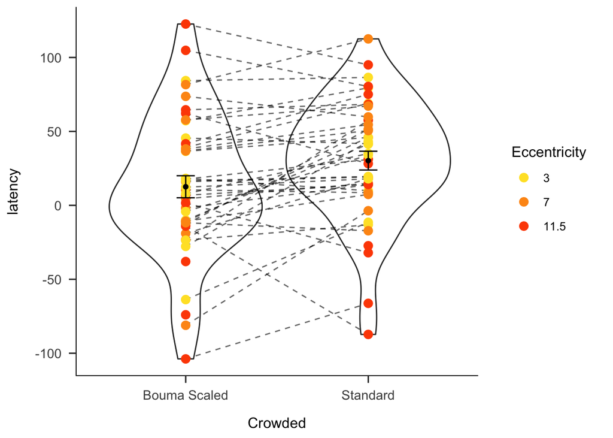

```r
paramsForAnalysis %<>% mutate(ringID = paste(ring, ID))

ggplot(paramsForAnalysis, aes(x=crowded, y = latency))+
  geom_violin(position = 'dodge')+
  geom_line(aes(group = interaction(ID,eccentricity)), position = 'dodge', linetype = 'dashed', alpha = .6)+
  geom_point(aes(group = ID, colour = factor(eccentricity)), position = 'dodge', size = 3)+
  stat_summary(geom = 'point', aes(group = crowded),fun.y = mean, position = position_dodge(.9))+
  stat_summary(geom= 'errorbar', aes(group = crowded), fun.data = mean_se, position = position_dodge(.9), width = .1)+
  #facet_wrap(~crowded)+
  scale_x_discrete(name = 'Crowded', labels = c('Bouma Scaled', 'Standard'))+
  scale_colour_manual(values = c('3' = '#FFE22E', '7' = '#FE9717', '11.5' = '#FE4D01'), name = 'Eccentricity')+
  theme_apa()
```

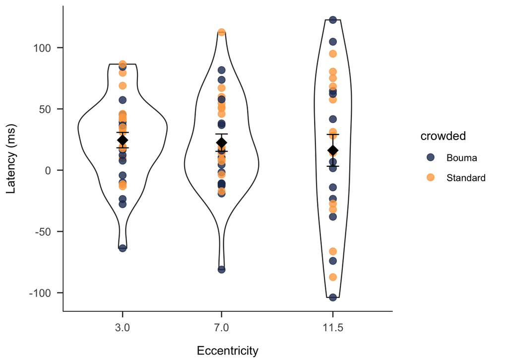

```r
ggplot(paramsForAnalysis, aes(x=eccentricity, y = latency))+
  geom_violin(position = 'dodge', aes(group = eccentricity))+
  #geom_line(aes(group = interaction(ID,crowded)), position = 'dodge', linetype = 'dashed', alpha = .6)+
  geom_point(aes(group = ID, colour = crowded), position = 'dodge', size = 3, alpha = .8)+
  stat_summary(geom = 'point', aes(group = eccentricity),fun.y = mean, position = position_dodge(.9), size = 5, , shape = 18)+
  stat_summary(geom= 'errorbar', aes(group = eccentricity), fun.data = mean_se, position = position_dodge(.9), width = .5)+
  #facet_wrap(~eccentricity)+
  scale_x_continuous(name = 'Eccentricity', breaks = c(3,7,11.5))+
  labs(y = 'Latency (ms)')+
  scale_colour_manual(values = c("Bouma"='#23375f', 'Standard' = '#ffa951'))+
  theme_apa()
```

We see the effect in our data.